# College Football Games and Crimes

Nabin Oli & Nava Nizard

2026-06-23

## Table 2: Distribution of Game Days by Day of the Week

| Day of Week | Games | Observations |
| --- | --- | --- |
| Sun | 7 | 2522 |
| Mon | 2 | 2522 |
| Tue | 1 | 2522 |
| Wed | 3 | 2522 |
| Thu | 51 | 2496 |
| Fri | 17 | 2522 |
| Sat | 866 | 2522 |
| Total | 947 | 17628 |

## Distribution of Offenses on Saturdays

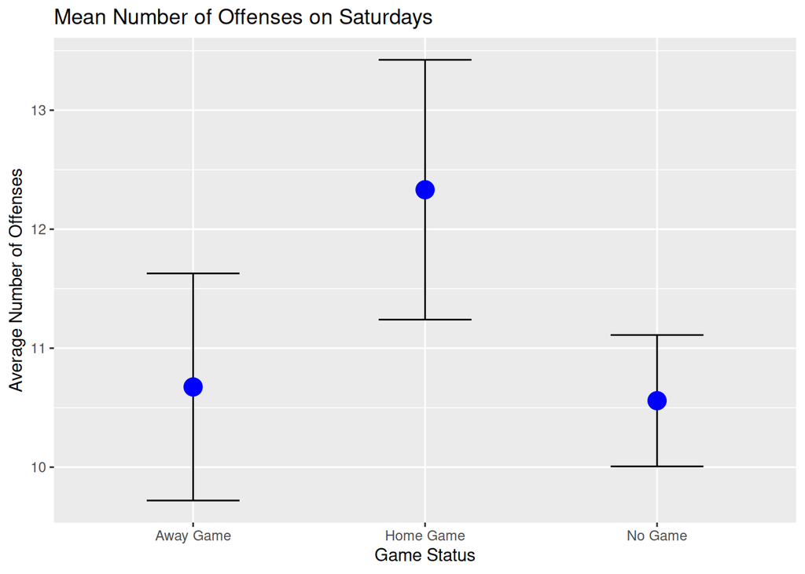

## Distribution of Offenses on Saturdays By Team

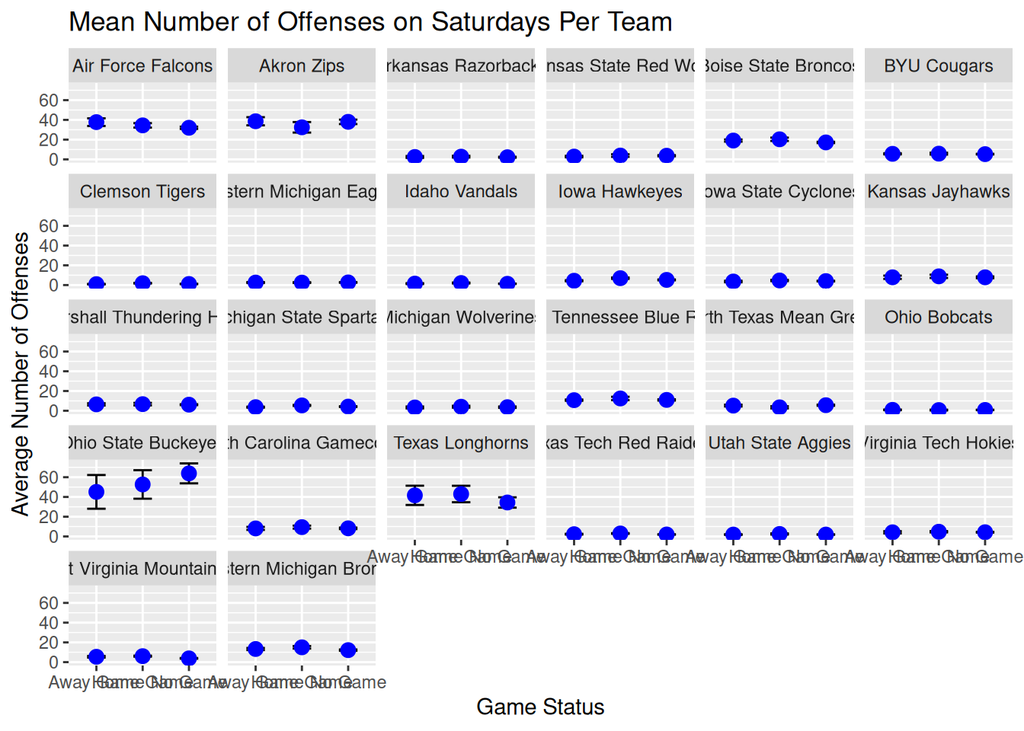

## Appendix: Descriptive Statistics for Count Variables

| offense | Stats | All Days | No Game | Home Game | Away Game |
| --- | --- | --- | --- | --- | --- |
| assault | mean | 4.536589 | 4.466812 | 5.958188 | 5.219316 |
| assault | std | 9.639039 | 9.506547 | 12.352515 | 10.298087 |
| assault | Q1 | 0.000000 | 0.000000 | 0.000000 | 0.000000 |
| assault | Q2 | 1.000000 | 1.000000 | 2.000000 | 1.000000 |
| assault | Q3 | 5.000000 | 5.000000 | 6.000000 | 5.000000 |
| assault | Q4 | 11.000000 | 11.000000 | 14.000000 | 13.000000 |
| vandalism | mean | 4.466757 | 4.395060 | 6.000000 | 5.084507 |
| vandalism | std | 10.818816 | 10.764745 | 12.541450 | 10.330082 |
| vandalism | Q1 | 0.000000 | 0.000000 | 0.000000 | 0.000000 |
| vandalism | Q2 | 1.000000 | 1.000000 | 2.000000 | 2.000000 |
| vandalism | Q3 | 4.000000 | 4.000000 | 6.000000 | 5.000000 |
| vandalism | Q4 | 11.000000 | 11.000000 | 16.000000 | 14.000000 |

## Table 3: College Football Games and Number of Offenses

### Linear Model

College Football Games and Number of Offenses

|  | Assaults | Vandalism |
| --- | --- | --- |
| Home game | 0.330 | 0.246 |
|  | (0.357) | (0.417) |
| Away game | -0.167 | -0.259 |
|  | (0.377) | (0.440) |
| Observations | 17628 | 17628 |
| Agency fixed effects | Yes | Yes |
| Groups | 26 | 26 |

+ p < 0.1, * p < 0.05, ** p < 0.01, *** p < 0.001

### Negative Binomial Model

College Football Games and Number of Offenses

|  | Assaults | Vandalism |
| --- | --- | --- |
| Home game | 0.108+ | 0.121* |
|  | (0.056) | (0.057) |
| Away game | -0.076 | -0.036 |
|  | (0.061) | (0.061) |
| Observations | 17628 | 17628 |
| Log likelihood | -35114.97 | -35554.16 |
| Agency fixed effects | Yes | Yes |
| Groups | 26 | 26 |

+ p < 0.1, * p < 0.05, ** p < 0.01, *** p < 0.001

### Conclusion

Comparing our linear regression results to the original table from the paper, neither the home-game nor away-game coefficients were statistically significant predictors of assaults or vandalism in the linear models. In contrast, the original paper reported that home games were associated with approximately a 9% increase in assaults and an 18% increase in vandalism, both with p-values below 0.01.

To further investigate this discrepancy, we fit a negative binomial model, following the methodology described in the original paper. The results showed that home games were associated with an estimated 11.3% increase in assaults and a 12.9% increase in vandalism. However, only the vandalism effect was statistically significant at the alpha = 0.05 level (p = 0.034), while the assault effect was borderline significant (p = 0.055). Away games were not statistically significant predictors in either model. Overall, these findings partially support the paper’s conclusion that home games are associated with increased offense rates, although we were unable to fully replicate the magnitude and statistical significance of the original results.

## Table 4: Winning Versus Losing

### Linear Model

Winning Versus Losing

|  | Assaults | Vandalism |
| --- | --- | --- |
| Home game win | 0.320 | 0.049 |
|  | (0.415) | (0.484) |
| Home game loss | 0.359 | 0.672 |
|  | (0.569) | (0.664) |
| Away game win | -0.462 | -0.735 |
|  | (0.556) | (0.649) |
| Away game loss | 0.043 | 0.078 |
|  | (0.463) | (0.541) |
| Observations | 17628 | 17628 |
| Agency fixed effects | Yes | Yes |
| Groups | 26 | 26 |

+ p < 0.1, * p < 0.05, ** p < 0.01, *** p < 0.001

### Negative Binomial Model

Winning Versus Losing

|  | Assaults | Vandalism |
| --- | --- | --- |
| Home game win | 0.114+ | 0.100 |
|  | (0.064) | (0.066) |
| Home game loss | 0.095 | 0.167+ |
|  | (0.091) | (0.092) |
| Away game win | -0.068 | -0.096 |
|  | (0.087) | (0.090) |
| Away game loss | -0.078 | 0.006 |
|  | (0.076) | (0.076) |
| Observations | 17628 | 17628 |
| Log likelihood | -35115.02 | -35553.55 |
| Agency fixed effects | Yes | Yes |
| Groups | 26 | 26 |

+ p < 0.1, * p < 0.05, ** p < 0.01, *** p < 0.001

### Conclusion

Comparing our linear regression results to the original paper, none of the home-game or away-game outcome variables were statistically significant predictors of assaults or vandalism. In contrast, the original study reported significant effects for both home-game wins and home-game losses.

To further investigate this discrepancy, we fit negative binomial models that matched the methodology used in the original paper. Although some p-values decreased in the negative binomial models, none reached statistical significance at the alpha = 0.05 level. Therefore, we were unable to replicate the paper’s finding that home-game outcomes significantly affect assault and vandalism rates. Consistent with the original paper, away-game outcomes did not appear to have a statistically significant effect.